# ggplot2_boxplot

### 상자그림 (Boxplot) 그리기

상자그림(boxplot)은 데이터의 분포(퍼져있는 형태)를 직사각형 상자모양으로 표현한 그래프.  
상자그림을 보면 분포를 알 수 있기 때문에 평균만 볼 때보다 데이터의 특성을 좀 더 자세히 이해할 수 있음.

```r
library(dplyr)
```

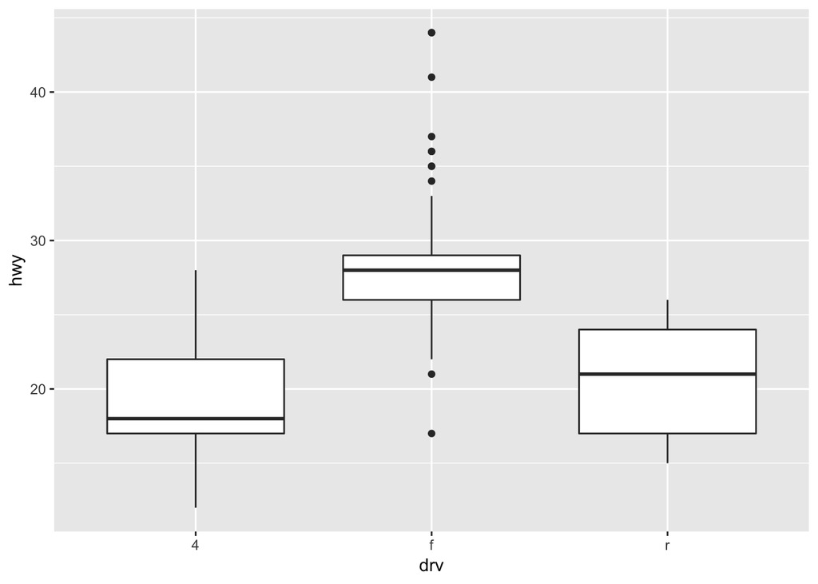

```r
library(ggplot2)
ggplot(mpg, aes(x = drv, y = hwy)) +
  geom_boxplot()
```

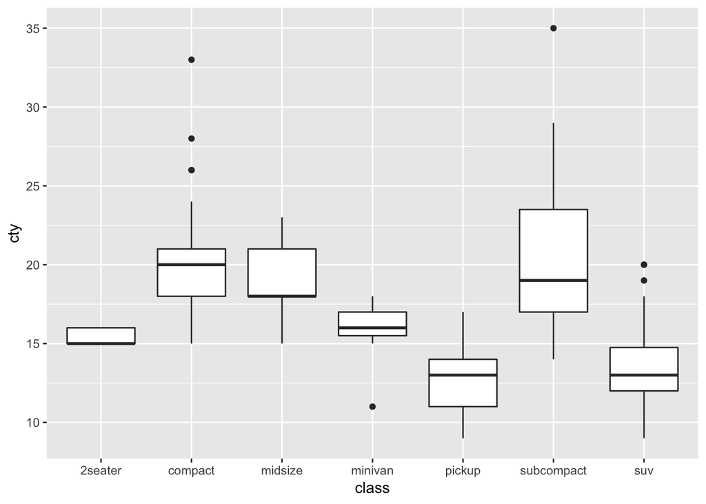

```r
ggplot(mpg, aes(x = class, y = cty)) +
  geom_boxplot()
```

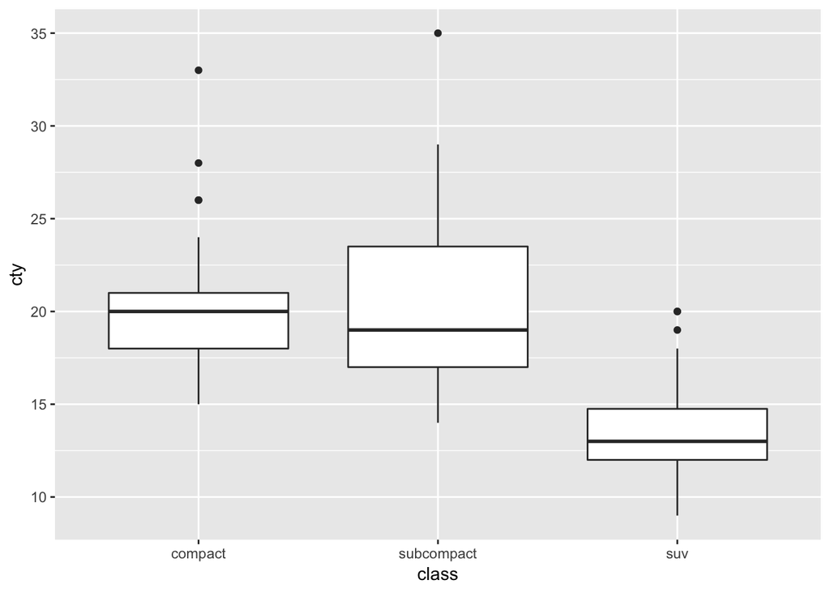

```r
library(dplyr)
mpg_class <- mpg %>%
  filter(class %in% c("compact", "subcompact", "suv"))

ggplot(mpg_class, aes(x = class, y = cty)) +
  geom_boxplot()
```

factor() 를 이용하여 수치형 변수를 이산형으로 변환

```r
library(MASS)
```

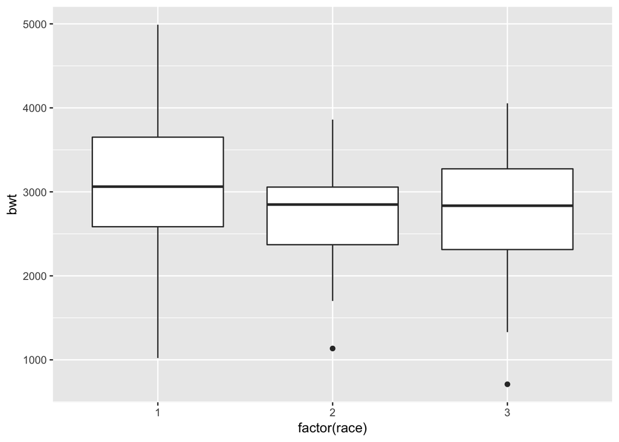

```r
ggplot(birthwt, aes(x = factor(race), y = bwt)) +
  geom_boxplot()
```

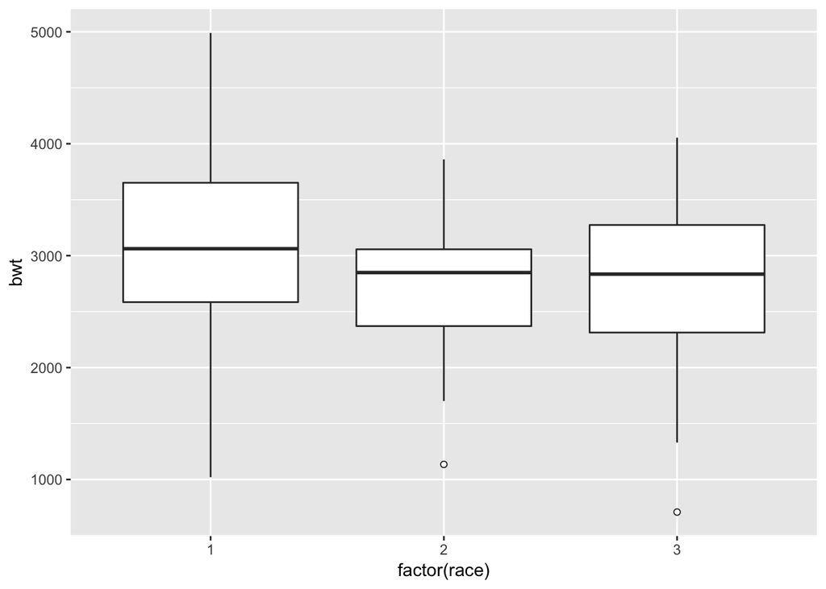

```r
ggplot(birthwt, aes(x = factor(race), y = bwt)) +
  geom_boxplot(outlier.size = 1.5, outlier.shape = 21)
```

#### 박스플롯에 V 모양 추가하기

- 박스플롯에서 분포의 중앙값이 다른지를 시각적으로 가늠해보기 위해 사용
- V모양이 겹치지 않으면 중앙값이 다르다는 말.

```
## notch went outside hinges. Try setting notch=FALSE.
```

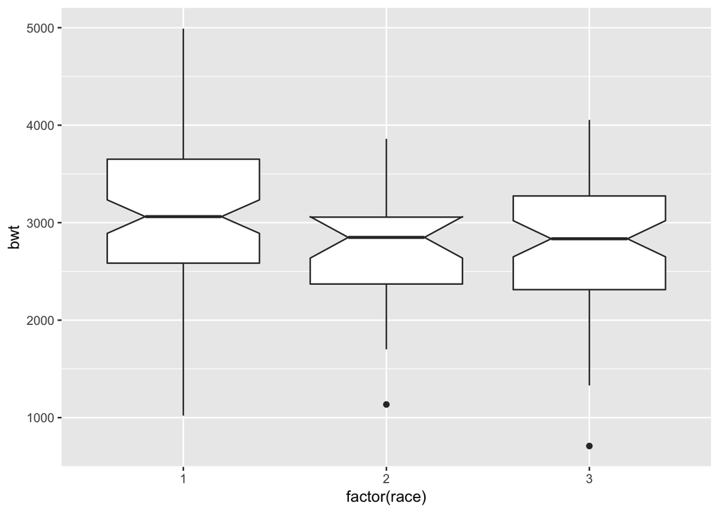

```r
ggplot(birthwt, aes(x = factor(race), y = bwt)) +
  geom_boxplot(notch = TRUE)
```

#### 박스플롯에 평균넣기

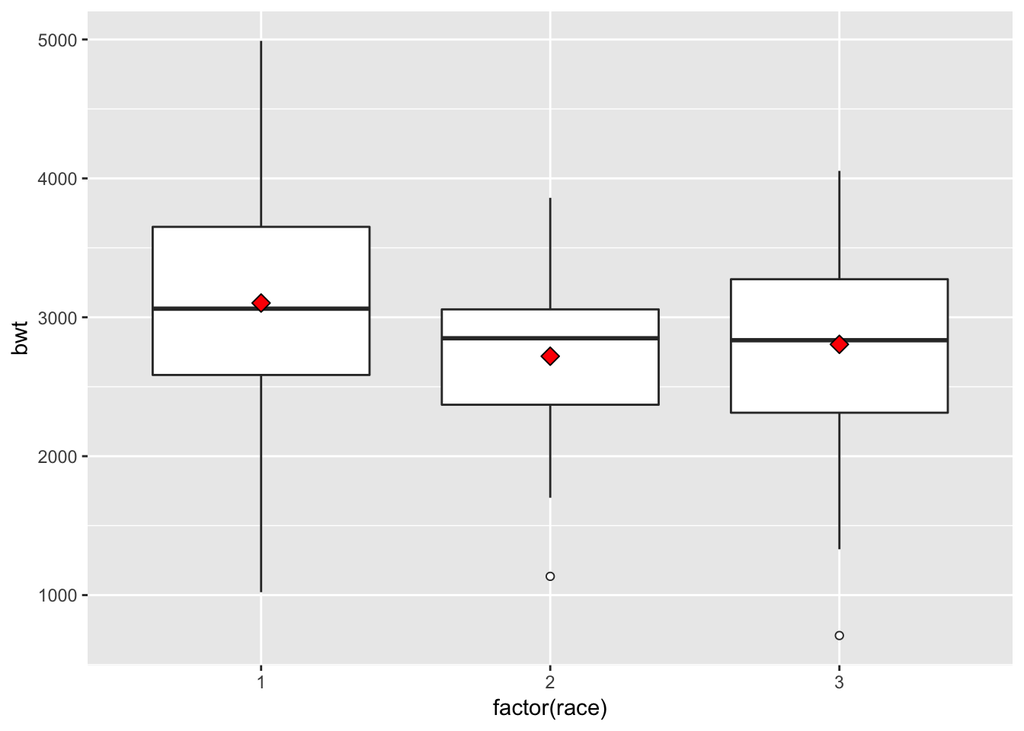

```r
ggplot(birthwt, aes(x = factor(race), y = bwt)) +
  geom_boxplot(outlier.size = 1.5, outlier.shape = 21) +
  stat_summary(fun.y = "mean", geom = "point", shape = 23, size = 3, fill = "red")
```

### 바이올린 그래프 그리기

여러집단의 밀도 추정치 비교

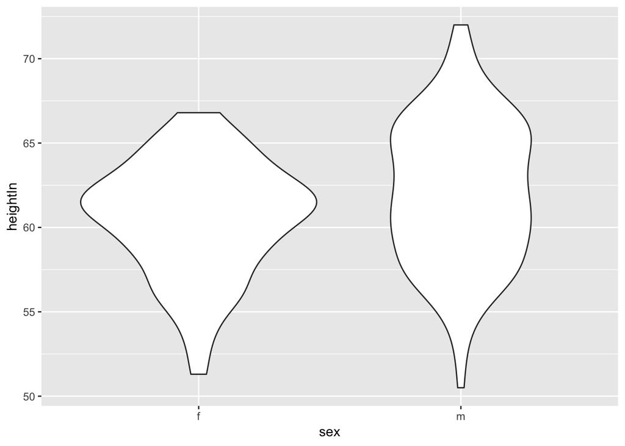

```r
library(gcookbook)
p <- ggplot(heightweight, aes(x = sex, y = heightIn))
p +  geom_violin()
```

- 바이올린 그래프는 다수의 데이터 분포를 비교할 때 사용
- 평범한 밀도곡선으로는 선들이 서로 겹치기 때문에 일정 개수 이상의 분포를 비교하기가 쉽지 않음.
- 바이올린 그래프를 보면 분포가 옆으로 나열되기 때문에 여러개를 비교하는 것이 용이함.
- 또한 전통적으로, 중앙값을 흰색점으로 표기한 얇은 박스플롯도 겹처 그림.
- outlier.colour = NA 로 설정하여 박스플롯에 있던 이상치는 보이지 않음.
- 꼬리를 유지하고 싶으면 trim = FALSE

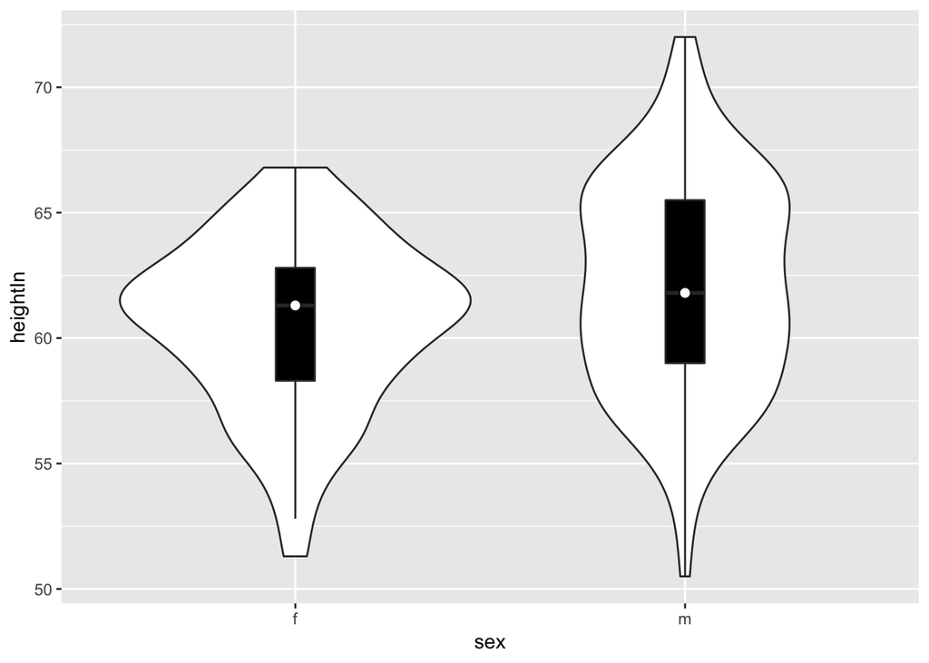

```r
p <- ggplot(heightweight, aes(x = sex, y = heightIn))
p +  geom_violin() +
  geom_boxplot(width = .1, fill = "black", outlier.colour = NA) +
  stat_summary(fun.y = median, geom = "point", fill = "white", shape = 21, size = 2.5)
```

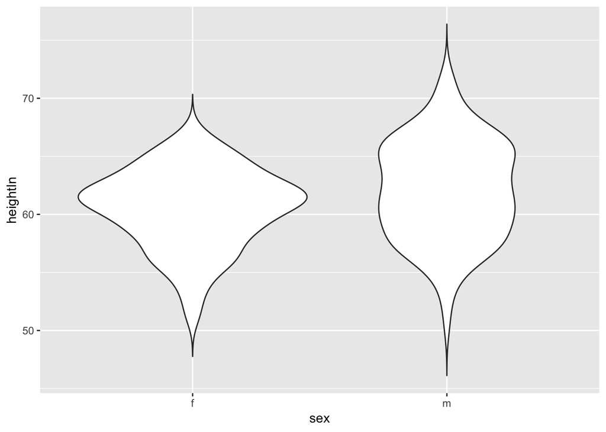

```r
p + geom_violin(trim = FALSE)
```

각 집단의 곽측개수에 비례하게 면접으로 조절하는 것도 가능. scale=“count”

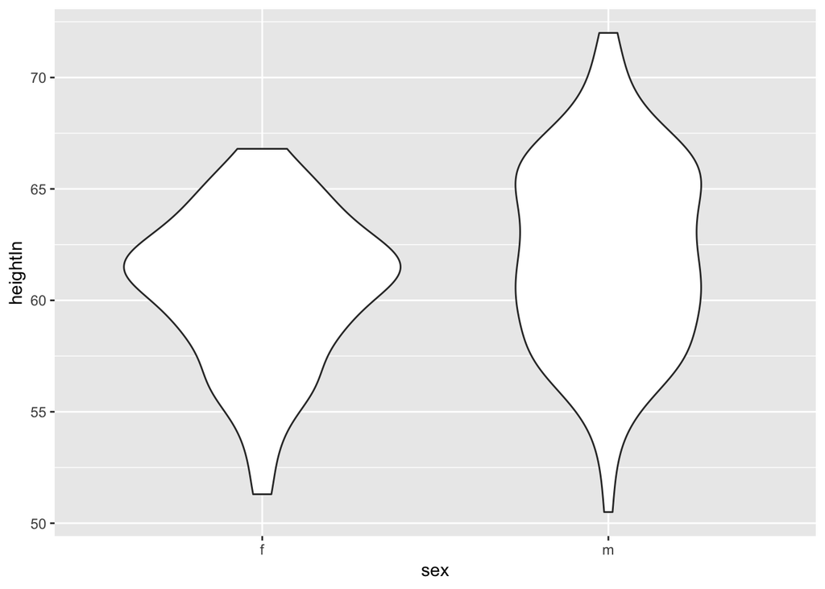

```r
p + geom_violin(scale = "count")
```

### 점 그래프 그리기

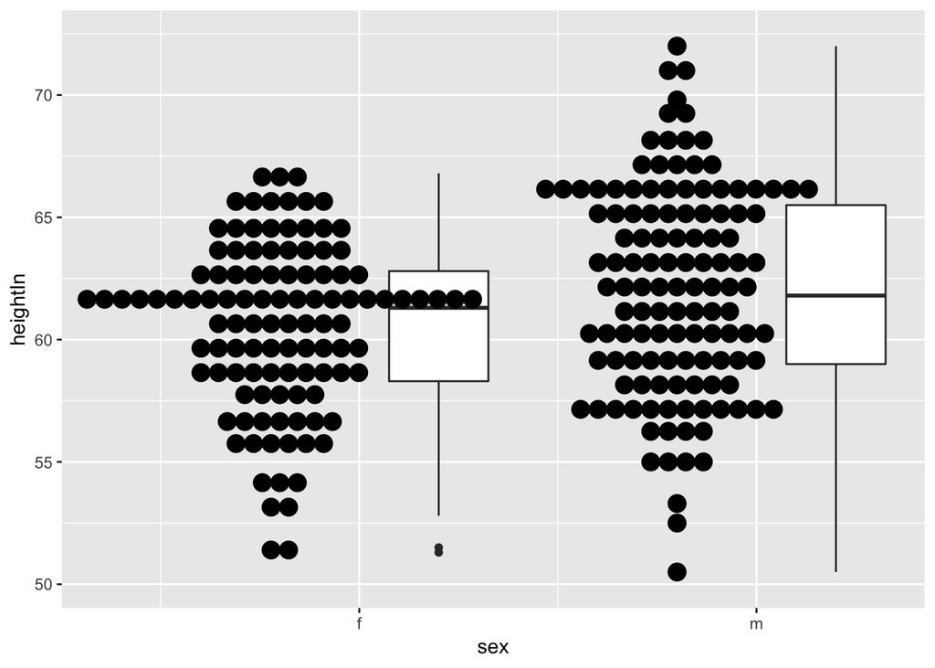

```r
ggplot(heightweight, aes(x = sex, y = heightIn)) +
  geom_boxplot(aes(x = as.numeric(sex) + .2, group = sex), width = .25) +
  geom_dotplot(aes(x = as.numeric(sex) - .2, group = sex), binaxis = "y",
               banwidth = .5, stackdir = "center") +
  scale_x_continuous(breaks = 1:nlevels(heightweight$sex),
                     labels = levels(heightweight$sex))
```

### 2차원 데이터의 밀도그래프

- stat_density2d() 사용 : 데이터로부터 2D 커널 밀도 추정치를 만듦

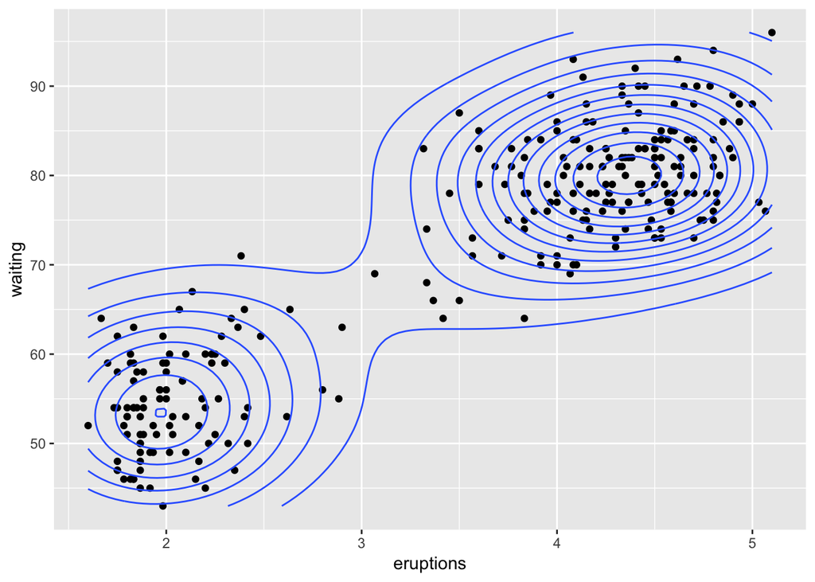

```r
p <- ggplot(faithful, aes(x = eruptions, y = waiting))
p + geom_point() + stat_density2d()
```

..level..을 통해 밀도곡선의 ’높이’를 등고선의 색상에 대입할 수도 있음.

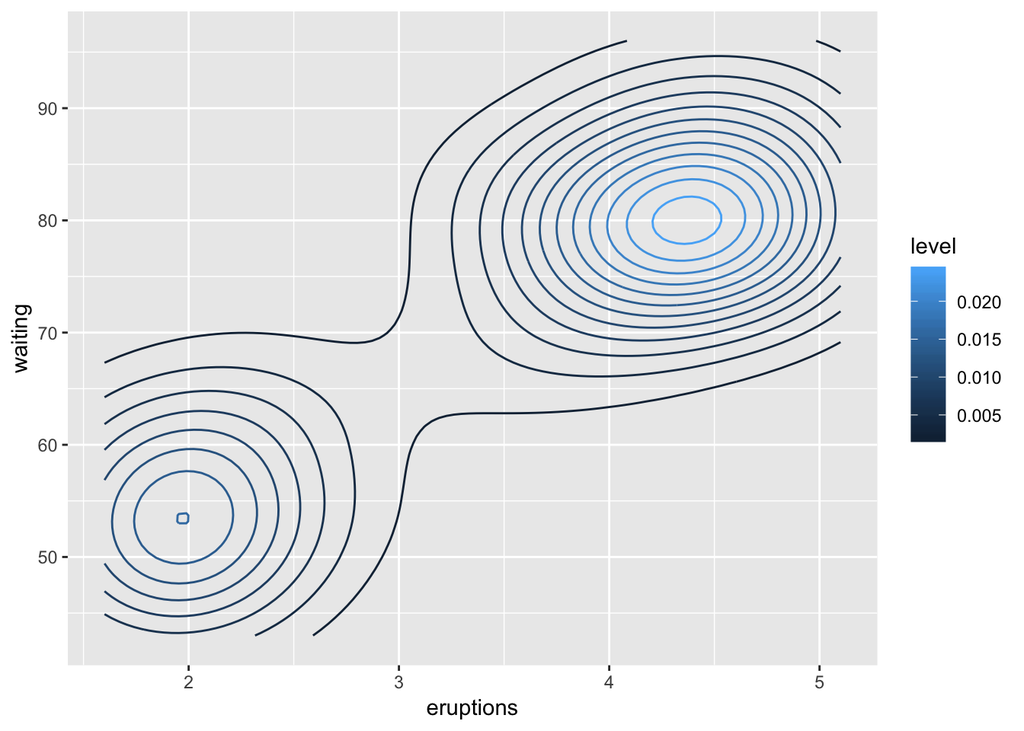

```r
p + stat_density2d(aes(colour = ..level..))
```

밀도 추정치를 채우기 색상에 대입

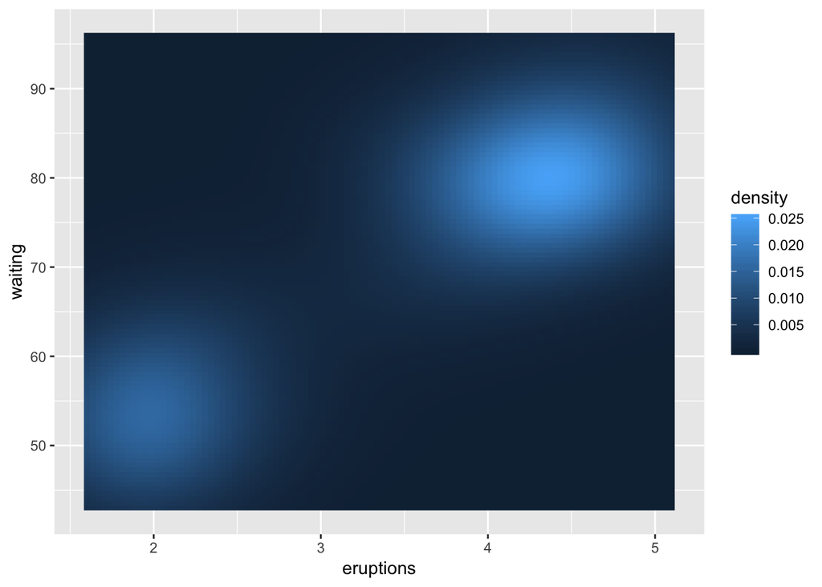

```r
p + stat_density2d(aes(fill = ..density..), geom = "raster", contour = FALSE)
```

점을 나타내고, 밀도추정치를 alpha 에 대입

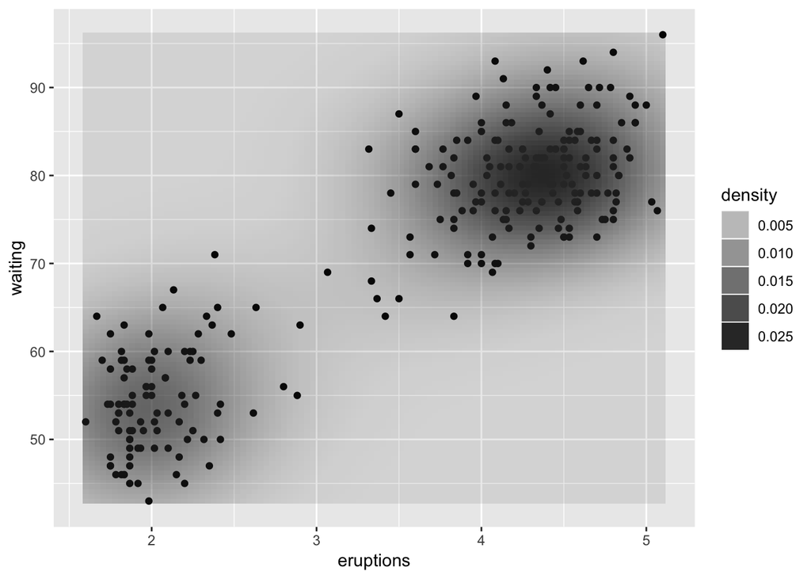

```r
p + geom_point() +
  stat_density2d(aes(alpha = ..density..), geom = "tile", contour = FALSE)
```

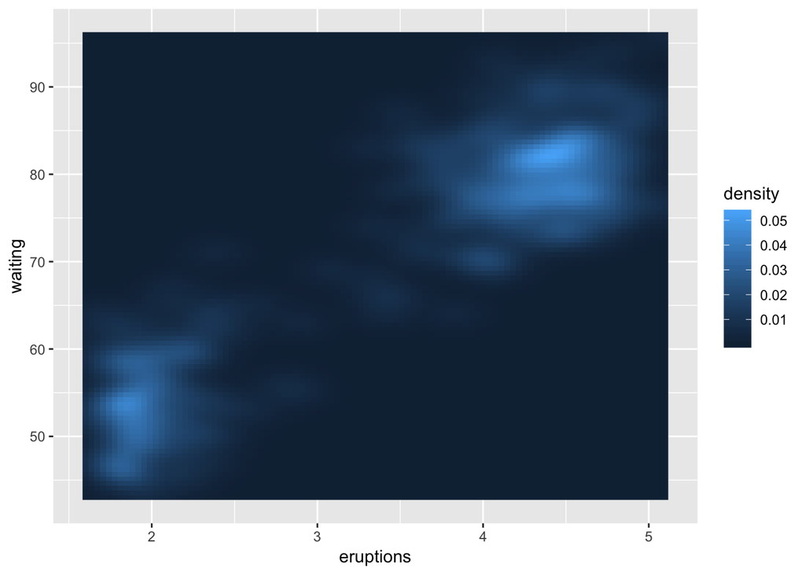

```r
p + stat_density2d(aes(fill = ..density..), geom = "raster", contour = FALSE, h = c(.5, 5))
```